# STAT 441: Introduction to Linear Models

## Learning Objectives:

In this lesson students will learn …

- The basics of R
  - Random variable functions built into R
  - Variable assignment
  - How to use simple mathematical functions in R to define relationships
- Plotting in base R
- Optional: plotting with ggplot

## Example 1: Creating Linear Relationships

### 1. Variable Assignment

In R you can use the equals sign `=` or the arrow `<-` to do variable assignment.

### 2. Generating Data in R

There are several distributions built into base R, from which you can draw values.

#### Uniform Distribution

Learn about the `runif` function

```r
### HELP
?runif
help(runif)
```

##### Question

What are the arguments for the `runif` function? What are the default values?

```
## YOUR NOTES HERE ##
```

##### Activity

###### Step 1

Generate 100 random numbers from the interval (0,1) and call it `X`

```r
### Generate 100 random numbers from the interval (0,1) and call it X

X<-runif(n=100, min=0, max=1)
```

Create a histogram to look at the data.

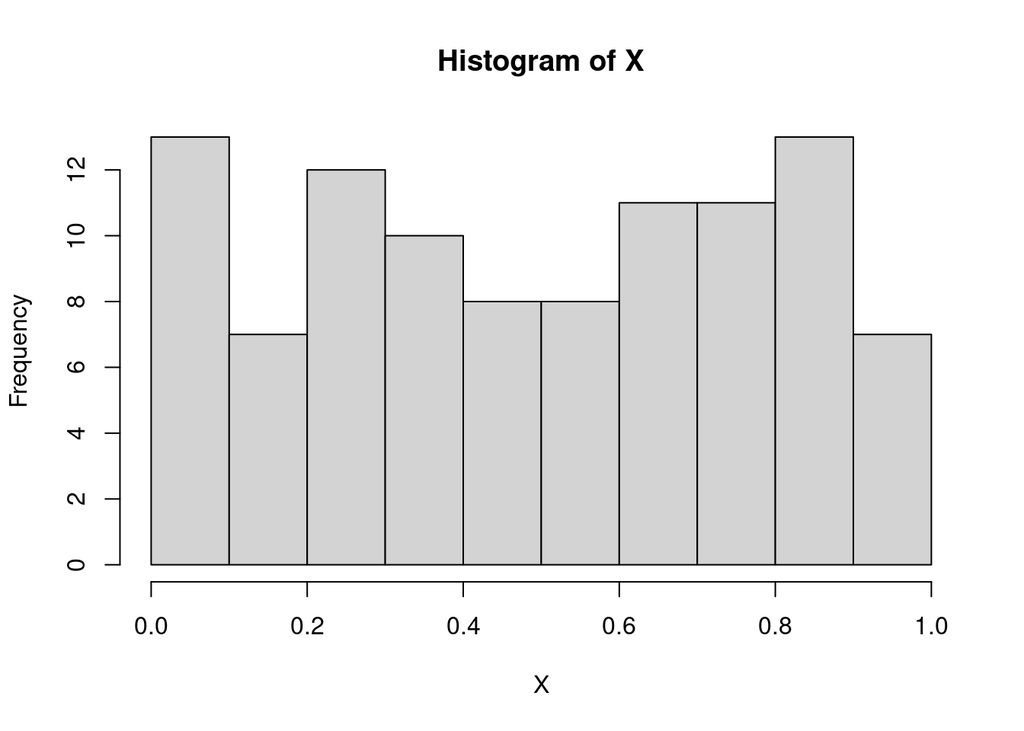

```r
### Histogram in Base R
hist(X)
```

###### Step 2

Generate 100 random numbers from the interval (0,1) and call it W

```r
### Generate 100 random numbers from the interval (0,1) and call it W

W<-runif(n=100, min=0, max=1)
```

###### Step 3

Define Y to be a linear combination of X and W, where
$$Y=0.15X + 0.85W$$

```r
### Define Y to be a linear combination of X and W

Y<-0.15*X + 0.85*W
```

###### Step 4

Make a scatterplot of (X,W)

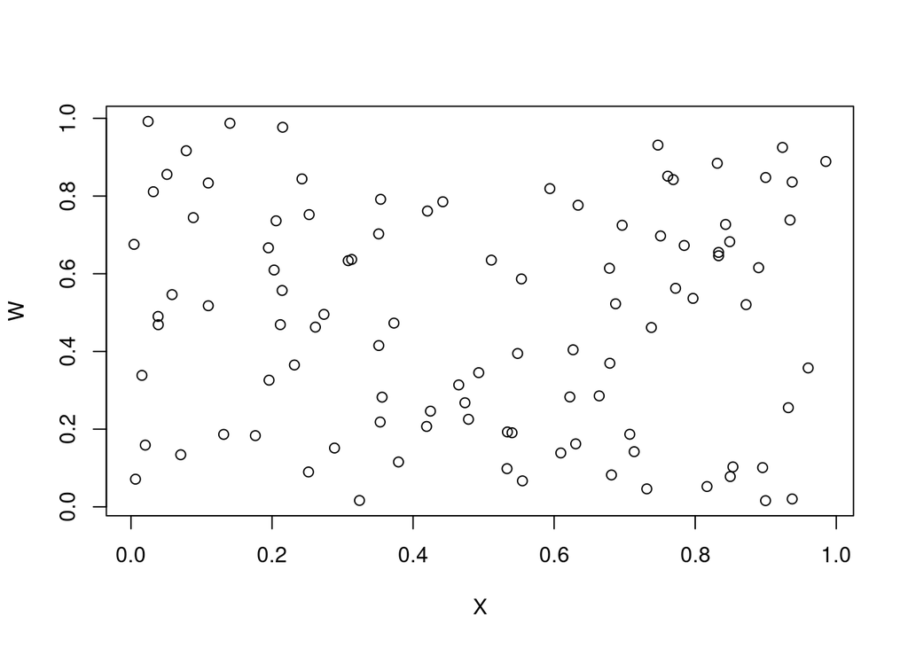

```r
### SCATTERPLOT IN BASE R
plot(X, W)
```

##### Question

How would you describe the relationship between X and W?

```
## YOUR NOTES HERE
```

###### Step 5

Make a scatterplots of (X, Y) and (W, Y)

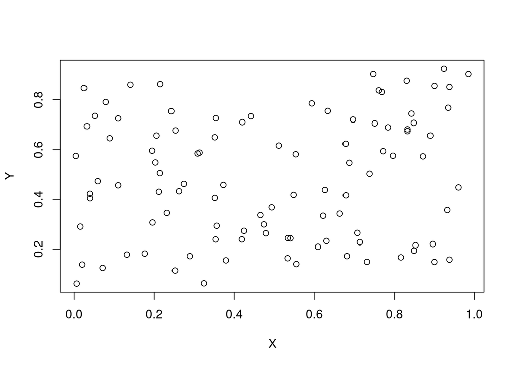

```r
### SCATTERPLOTS OF X,Y and W,Y
plot(X,Y)
```

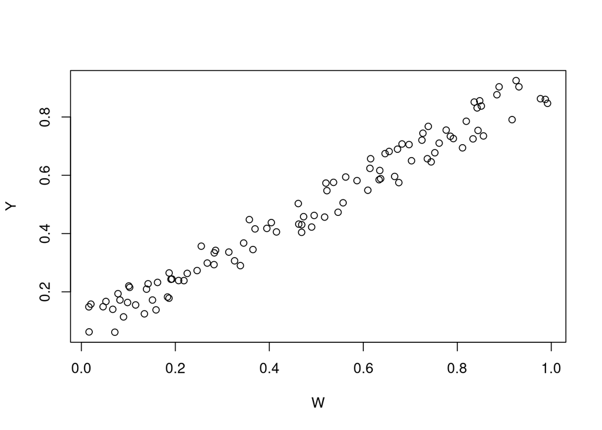

```r
plot(W,Y)
```

##### Question

Are these plots similar or different? Do you have a hypothesis about why they might look different?

```
## YOUR NOTES HERE
```

## Example 2: Linear Models

Consider the following examples of linear models:

- Simple Linear Regression: $Y=\beta_0+\beta_1 X$
- Polynomial Regression: $Y=\beta_0+\beta_1 X+ \beta_2 X^2$
- Log Transformation: $Y=\beta_0+\beta_1 ln(X)$
- Multiple Linear Regression: $Y=\beta_0+\beta_1 X_1+\beta_2 X_2$

##### Activity

Program examples of the models above and in R. Then create a scatter plot to visualize the relationship. Compare and contrast plots.

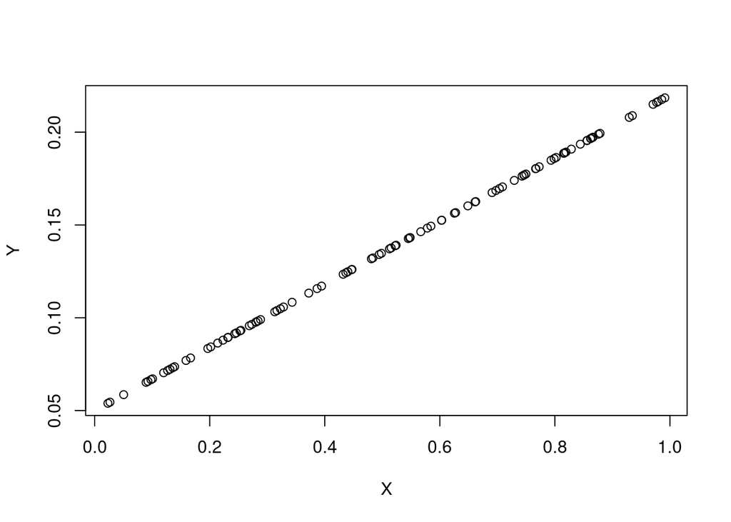

```r
### SIMPLE LINEAR
X<-runif(n=100)

### PARAMETERS
beta0<-.05
beta1<-.17

### MODEL
Y<-beta0+beta1*X

### PLOT
plot(X, Y)
```

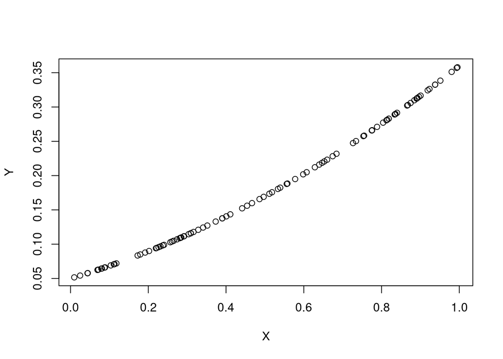

```r
### POLYNOMIAL LINEAR
X<-runif(n=100)

### PARAMETERS
beta0<-.05
beta1<-.17
beta2<-.14

### MODEL
Y<-beta0+beta1*X+beta2*X^2

### PLOT
plot(X, Y)
```

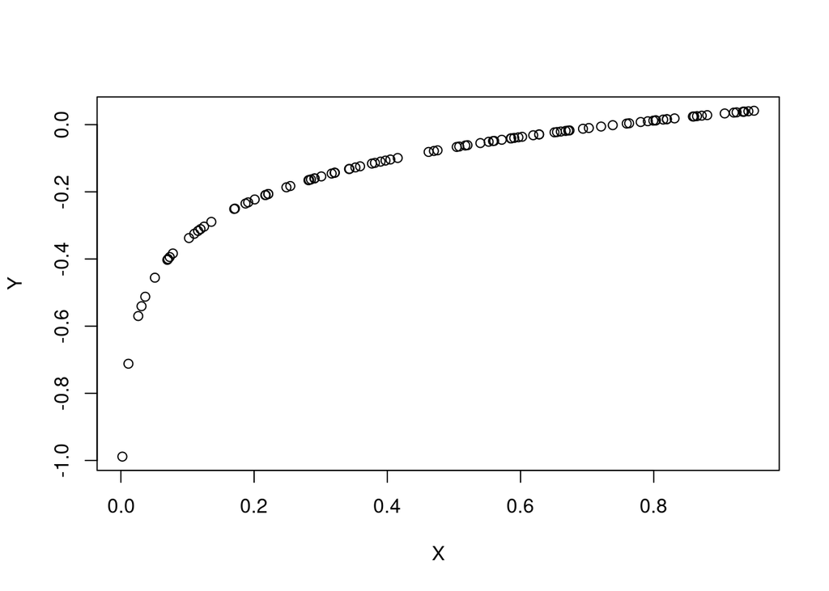

```r
### LOG TRANSFORMED
X<-runif(n=100)

### PARAMETERS
beta0<-.05
beta1<-.17

### MODEL
Y<-beta0+beta1*log(X)

### PLOT
plot(X, Y)
```

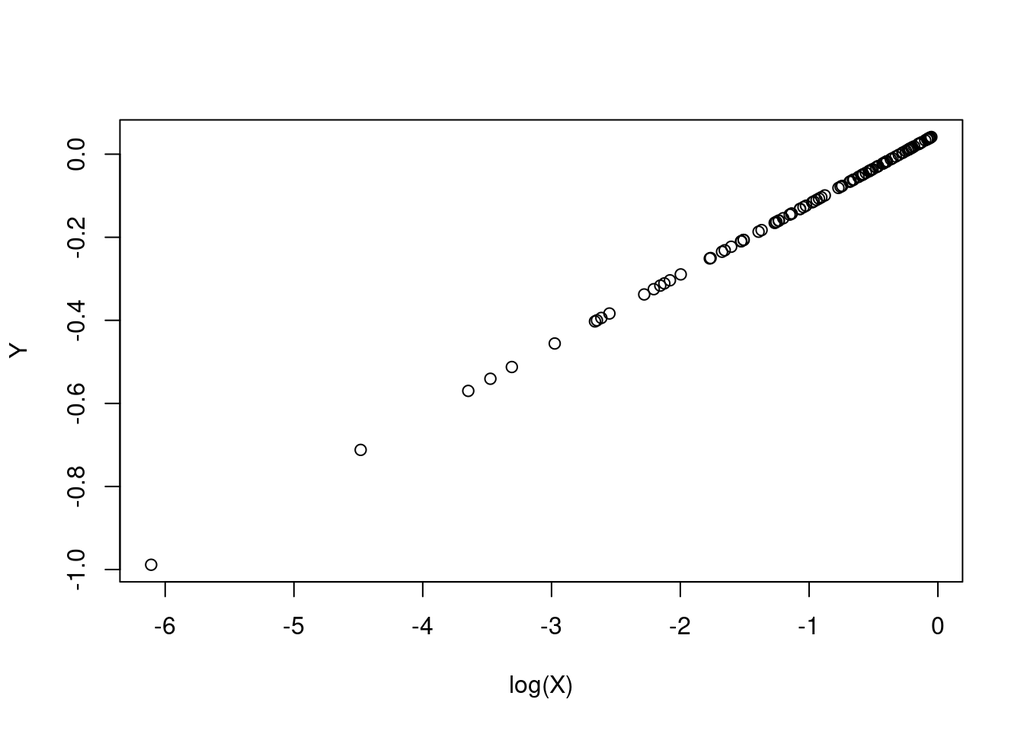

```r
plot(log(X), Y)
```

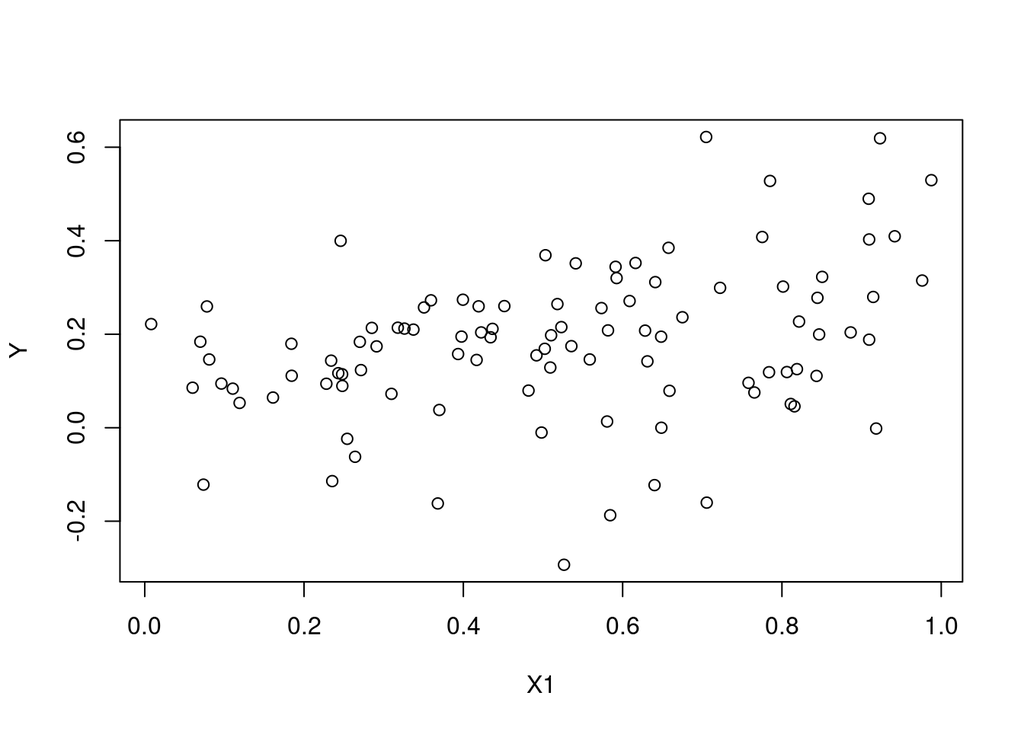

```r
### MULTIPLE
X1<-runif(n=100)
X2<-rnorm(n=100)

### PARAMETERS
beta0<-.05
beta1<-.17
beta2<-.16

### MODEL
Y<-beta0+beta1*X1+beta2*X2

### PLOT
plot(X1, Y)
```

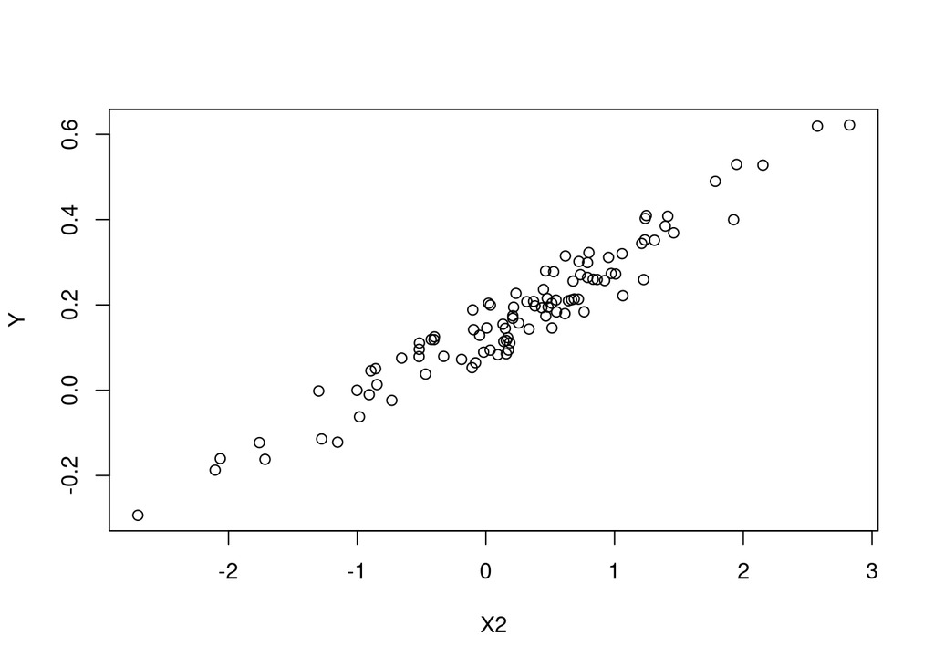

```r
plot(X2, Y)
```